# COVID-19 Georgia Weekly Forecast Summary

[The COVID-19 Forecast Hub Team](https://covid19forecasthub.org/doc/) https://covid19forecasthub.org/

2021-03-02

# Background

This report provides a brief summary of the weekly ensemble forecast for Georgia from the [COVID-19 Forecast Hub](https://covid19forecasthub.org/). In collaboration with the US CDC, our team aggregates COVID-19 forecasts from dozens of teams around the globe. Typically on Wednesday of each week, a summary of the week’s forecasts from the COVID-19 Forecast Hub appear on the [official CDC COVID-19 forecasting page](https://www.cdc.gov/coronavirus/2019-ncov/covid-data/forecasting-us.html).

Every week, teams submit their forecasts to the COVID-19 Forecast Hub.

Each Tuesday, we combine the most recent forecasts from each team into a single “ensemble” forecast of reported COVID-19 cases at the county, state, and national level and deaths at the state and national level. At the moment, we only generate ensemble forecasts for four weeks into the future, as [the available evidence](https://www.medrxiv.org/content/10.1101/2021.02.03.21250974v1) suggests that models are less accurate at longer forecast horizons.

Weekly reports from the COVID-19 Forecast Hub can be found at [this page](https://covid19forecasthub.org/doc/reports/).

# COVID-19 Mortality Forecasts

Since the inputs to the ensemble model do not factor in changes in behavior or policy that could have an impact on short-term disease transmission (e.g. school openings or closures, new interventions, governmental policy shift, etc…), the ensemble model itself should not be looked to for specific answers to questions like “what will happen if or when schools open in 2 weeks” because most of the input models are not factoring in these changes. That said, the ensemble model has consistently shown strong predictive performance, and very few of the many interventions put in place appear to have created dramatic changes in short-term disease transmission that would impact short-term trends in mortality.

## State level

This week, our ensemble combined forecasts for Georgia from 45 different models.

At the state level, the ensemble model predicts that weekly totals of observed deaths in each of the next four weeks will be between 385 and 534 deaths each week with around 19,200 total deaths by March 27 (Figure 1). However for the week ending March 27, the ensemble shows substantial uncertainty, with observed deaths between 170 and 670 deemed possible (95% prediction interval: 173 - 670).

During periods of relative stability, models in general show broad agreement about the predicted trajectory of the outbreak. However, when there are steep surges or declines in cases or deaths, models often have quite different predictions for the upcoming weeks. The result is that there is increased uncertainty in the ensemble forecast, which can be seen as wider confidence intervals in the forecast visualization. You can explore the full set of models, including their forecasts for past weeks online at our [interactive forecast visualization](https://viz.covid19forecasthub.org/).

Figure 1: Weekly observed and forecasted COVID-19 deaths. Observed data from [JHU CSSE](https://github.com/CSSEGISandData/COVID-19/tree/master/csse_covid_19_data/) and forecasts from the [COVID-19 Forecast Hub](https://covid19forecasthub.org/).

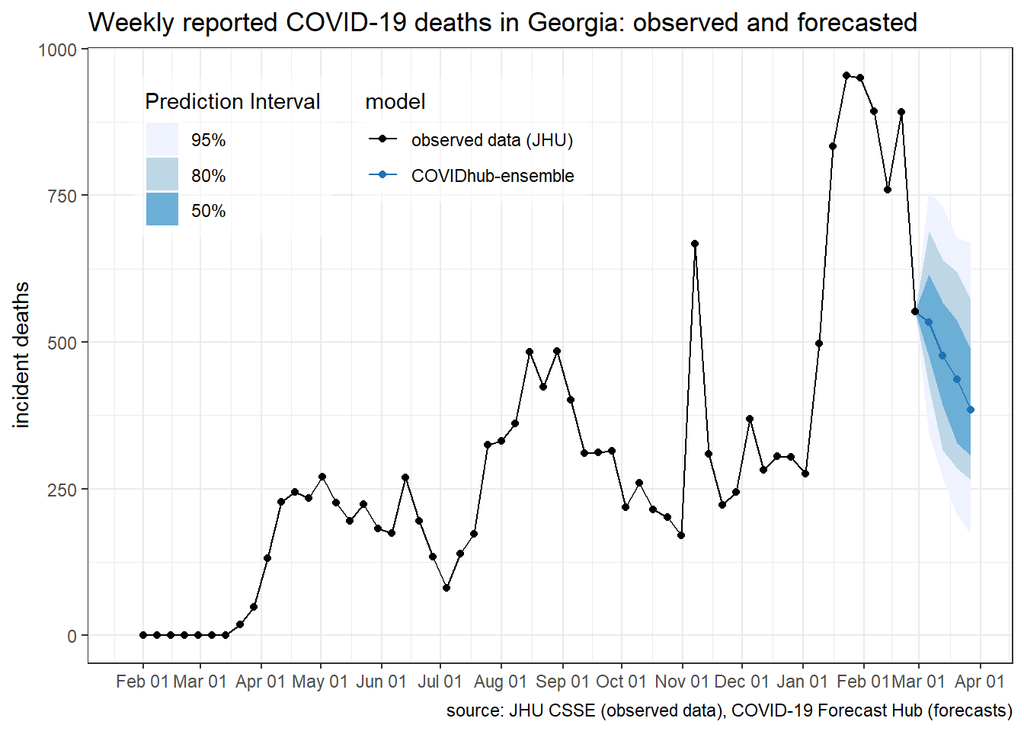

For state-level death forecasts made over the last 6 weeks in Georgia for which observed data are now available, the 95% prediction intervals covered the truth 94% of the time, and the 50% prediction intervals covered the truth 66% of the time.

The sortable and searchable table below shows the total number of reported COVID-19 deaths at the US level and for Georgia over the last two weeks (February 14, 2021 to February 27, 2021) and the forecasted counts for the subsequent two weeks (February 28, 2021 to March 13, 2021).

[interactive table not shown]

# COVID-19 Incident Case Forecasts

## State level

At the state level, the ensemble model predicts that weekly totals of observed cases in each of the next four weeks will be between 14,500 and 18,500 cases each week (Figure 2). However for the week ending March 27, the ensemble shows substantial uncertainty, with observed cases between 5,200 and 34,900 deemed possible (95% prediction interval: 5,155 - 34,907).

You can explore the full set of models, including their forecasts for past weeks online at our [interactive forecast visualization](https://viz.covid19forecasthub.org/).

Figure 2: Weekly observed and forecasted COVID-19 cases. Observed data from [JHU CSSE](https://github.com/CSSEGISandData/COVID-19/tree/master/csse_covid_19_data/) and forecasts from the [COVID-19 Forecast Hub](https://covid19forecasthub.org/).

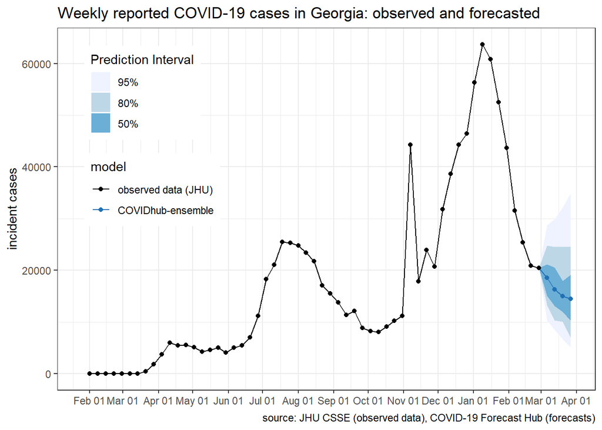

The sortable and searchable table below shows the total number of reported COVID-19 cases at the US and state level for Georgia as of Saturday, February 27, 2021 (“Total COVID-19 Cases”), as well as the weekly case count and rate of reported COVID-19 cases in the population (standardized per 100,000 population) over the last week (February 21, 2021 to February 27, 2021) and two weeks ahead (March 07, 2021 to March 13, 2021).

When interpreting probability of an increase, it’s important to note that the increase or decrease is relative to the location-specific recent observed incidence, which varies across locations.

[interactive table not shown]

## County level

County-level case forecasts are presented in Table 3. Cases reported in unknown counties or by people who reside outside of the state are not included in Table 3, but are included in the state-level data.

[interactive table not shown]

Select a County

[interactive chart not shown]

This report was reproducibly and dynamically generated using RMarkdown. The code for the report can be found [here](https://github.com/reichlab/covid19-forecast-hub/tree/master/code/reports).